Skip to main content

# Monte Carlo Method

- Show All Code
- Hide All Code
- View Source

Sampling methods and variance reduction

Author

Sanyang Liu

Monte Carlo starts with two practical questions. How can we generate draws from a target distribution? Once we can sample from it, how can we estimate an expectation more precisely for the same amount of computation? The examples below use NumPy and compare the simulation results with known benchmarks.

# Sampling methods

Uniform draws are the starting point for both inverse transform and rejection sampling. A linear congruential generator gives us a simple way to see how a stream of pseudo-random uniforms is made.

## Linear congruential generators

**NoteAlgorithm: Linear congruential generator**

Choose an integer modulus $m\geq 2$, multiplier $a$, increment $c$, and seed $X_0\in\{0,\ldots,m-1\}$. For $i\geq 1$, compute
$$X_i=(aX_{i-1}+c)\bmod m,
\qquad
U_i=\frac{X_i}{m}.$$
The values $U_i\in[0,1)$ are **pseudo-random numbers** intended to approximate draws from $\mathrm{Uniform}(0,1)$.

**A generator with a short period.** With $(a,c,m)=(7,3,16)$ and seed $X_0=5$, the generator returns to the seed after four steps. The table also shows the rescaling $Y_i=2+3U_i$ to $[2,5)$, which preserves the four-step cycle.

**Show Python code**

```python
def lcg(seed, a, c, m, n):
    out = np.empty(n, dtype=np.int64)
    x = seed
    for j in range(n):
        x = (a * x + c) % m
        out[j] = x
    return out

seed = 5
a = 7
c = 3
m = 16
n = 20

X = lcg(seed, a, c, m, n)
U = X / m
Y = 2 + 3 * U
```

| Indices *i* | *X*<sub>i</sub> | *U*<sub>i</sub> | *Y*<sub>i</sub> |
| --- | --- | --- | --- |
| 0 (seed) | 5 | — | — |
| 1, 5, 9, 13, 17 | 6 | 0.3750 | 3.1250 |
| 2, 6, 10, 14, 18 | 13 | 0.8125 | 4.4375 |
| 3, 7, 11, 15, 19 | 14 | 0.8750 | 4.6250 |
| 4, 8, 12, 16, 20 | 5 | 0.3125 | 2.9375 |

Changing the parameters to $(a,c,m)=(5,1,2^{16})$ gives a full period of $65{,}536$ for this seed. The histogram checks how evenly the values fill $[0,1)$, and the scatter plot shows whether successive pairs form visible patterns.

**Show Python code**

```python
def period(seed, a, c, m):
    x = seed
    for j in range(1, m + 2):
        x = (a * x + c) % m
        if x == seed:
            return j
    raise ValueError("No return within m+1 steps")

print("Period with modulus 16:", period(5, 7, 3, 16))
print("Period with modulus 65,536:", period(5, 5, 1, 2**16))
```

```
Period with modulus 16: 4
Period with modulus 65,536: 65536
```

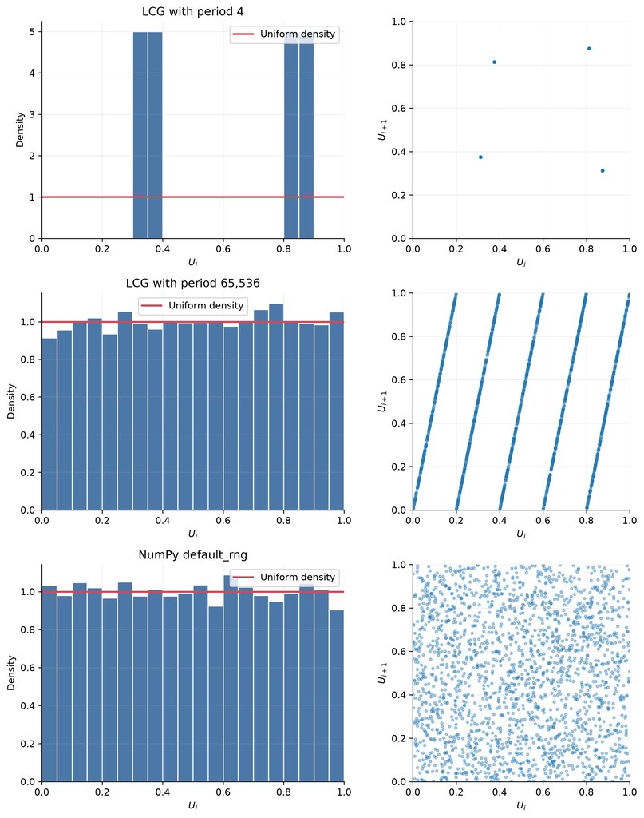

Figure 1: Histograms (left) and successive pairs (right) for two LCGs and NumPy’s default generator. The longer-period LCG fills the histogram more evenly, but its successive pairs form visible bands.

## Inverse transform sampling

Write $F_X(x)=\Pr(X\le x)$ for the cumulative distribution function (CDF) of $X$. If $X$ has a probability density function (PDF) $f_X$, then $F_X(x)=\int_{-\infty}^x f_X(t)\,dt$.

**NoteTheorem: Inverse transform sampling**

For a continuous random variable $X$ with CDF $F_X$, the random variable $U=F_X(X)$ is uniform on $[0,1]$. Define
$$F_X^{-1}(u)=\inf\{x\in\mathbb R:F_X(x)\ge u\},\qquad 0<u<1.$$
Since $F_X$ is continuous, $F_X(F_X^{-1}(u))=u$ and $\Pr(X<x)=F_X(x)$. Hence
$$\Pr(U<u)=\Pr(F_X(X)<u)=\Pr(X<F_X^{-1}(u))=F_X(F_X^{-1}(u))=u.$$

The sampling algorithm goes in the reverse direction. For any CDF $F_X$, $F_X^{-1}(u)\le x$ exactly when $u\le F_X(x)$. Thus a uniform draw $U$ gives $\Pr(F_X^{-1}(U)\le x)=\Pr(U\le F_X(x))=F_X(x)$.

**NoteAlgorithm: Inverse transform sampling**

1. Obtain the target CDF $F_X$. If the PDF $f_X$ is given, integrate it to find $F_X$.
2. Find the quantile function $F_X^{-1}$. When $F_X$ is continuous and strictly increasing on its support, solve $F_X(x)=u$ for $x$.
3. Draw independent $U_i\sim\mathrm{Uniform}(0,1)$ and return $X_i=F_X^{-1}(U_i)$.

**Exponential waiting times.** For $X\sim\mathrm{Exp}(\lambda)$ with $\lambda>0$, the density and CDF on $x\ge 0$ are
$$f_X(x)=\lambda e^{-\lambda x},\qquad F_X(x)=1-e^{-\lambda x}.$$
Both are zero for $x<0$. Solving $F_X(x)=u$ gives
$$F_X^{-1}(u)=-\frac{\log(1-u)}{\lambda}.$$

**NoteDefinitions: Sample mean and sample variance**

For a sample $X_1,\ldots,X_N$ from the distribution of $X$ with $N\ge 2$, define the sample mean and sample variance by
$$\mu_{X,N}=\frac{1}{N}\sum_{i=1}^N X_i,
\qquad
\sigma_{X,N}^2=\frac{1}{N-1}\sum_{i=1}^N(X_i-\mu_{X,N})^2.$$
The sample standard deviation is $\sigma_{X,N}=\sqrt{\sigma_{X,N}^2}$. The corresponding population quantities are $\mu_X=\mathbb E[X]$ and $\sigma_X^2=\operatorname{Var}(X)=\mathbb E[(X-\mu_X)^2]$ when these moments exist.

With $\lambda=1/2$, the theoretical mean is $2$ and the variance is $4$. The table compares these values with the sample mean and sample variance from 10,000 draws.

**Show Python code**

```python
rng = np.random.default_rng(490702)
x2 = -2*np.log1p(-rng.random(10_000))
table([[x2.mean(),x2.var(ddof=1),2,4]],
      ["Sample mean","Sample variance","True mean","True variance"])
```

|  | Sample mean | Sample variance | True mean | True variance |
| --- | --- | --- | --- | --- |
| 0 | 2.029487 | 4.074184 | 2 | 4 |

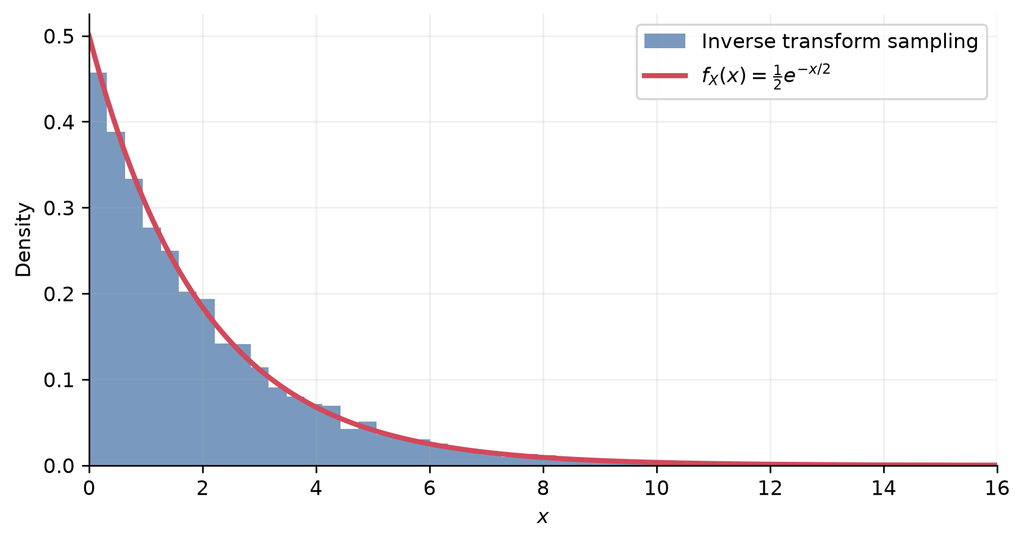

Figure 2: Histogram of 10,000 inverse transform samples from Exp(1/2), overlaid with the theoretical exponential density.

## Rejection sampling

When the target quantile is hard to evaluate, draw from an easier proposal and use an acceptance probability to recover the target density.

**NoteAlgorithm: Rejection sampling**

1. Choose a proposal density $f_Y$ and a finite constant $c$ such that $f_X(x)\le c f_Y(x)$ almost everywhere.
2. Draw $Y$ from the proposal and $U\sim\mathrm{Uniform}(0,1)$ independently.
3. If $U\le f_X(Y)/(c f_Y(Y))$, return $Y$. Otherwise, repeat step 2.

**TipChoosing the proposal density $f_Y$**

Choose a proposal that is easy to sample, is positive wherever the target is positive (up to sets of measure zero), and keeps $f_X/f_Y$ bounded. A uniform density is a first candidate for a bounded target density on a finite interval. On a half-line, try a shifted exponential if its tail is slow enough. On $\mathbb R$, try a normal for a light-tailed target or a Student $t$ for heavier tails. Check the ratio for the chosen parameters.

**TipChoosing the constant $c$**

Use the smallest bound that holds almost everywhere:
$$c_* = \operatorname*{ess\,sup}_{x:\, f_Y(x)>0}\frac{f_X(x)}{f_Y(x)}.$$
For a smooth ratio, find the supremum by checking stationary points, interval endpoints, and tail limits. The acceptance probability is $1/c$, so a smaller valid $c$ means fewer rejections.

The density of proposing and accepting a value near $y$ is $f_Y(y)\,f_X(y)/(c f_Y(y))=f_X(y)/c$. Integrating gives acceptance probability $1/c$. Conditioning on acceptance therefore gives density $f_X$.

**A quadratic density on $[0,1]$.** Take $f_X(x)=3x^2$ and $f_Y(x)=2x$ on this interval.

Here $f_X(x)/f_Y(x)=3x/2$ for $0<x\le 1$. The derivative is $3/2>0$, so the maximum is at $x=1$ and $c_*=3/2$. Draw $Y=\sqrt V$ with $V\sim\mathrm{Uniform}(0,1)$ and accept when $U\le Y$. A uniform proposal instead gives $c_*=3$ and accepts $1/3$ of proposals. If the target inverse CDF is available, here $X=U^{1/3}$, inverse transform sampling returns a sample on every draw.

**Show Python code**

```python
rng = np.random.default_rng(490703)
accepted, progress = [], []
proposals = 0
while len(accepted)<10_000:
    candidate=sqrt(rng.random())
    proposals+=1
    if rng.random()<=candidate:
        accepted.append(candidate)
    progress.append(len(accepted))
accepted=np.asarray(accepted)
table([[len(accepted),proposals,len(accepted)/proposals,2/3]],
      ["Accepted","Proposals","Empirical rate","Theory"])
```

|  | Accepted | Proposals | Empirical rate | Theory |
| --- | --- | --- | --- | --- |
| 0 | 10000 | 15100 | 0.662252 | 0.666667 |

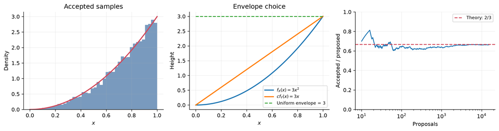

Figure 3: From left to right, the panels show the accepted draws against the target density, the envelopes from two proposals, and the observed acceptance rate approaching 2/3 for the linear proposal.

# Variance reduction

Start with crude Monte Carlo as a baseline. Its standard error scales as $\sigma_H/\sqrt N$, where $\sigma_H$ measures how much a single simulated value fluctuates. The methods that follow change how we generate or combine values to reduce the estimator variance at a comparable simulation cost.

## Crude Monte Carlo integration

**NoteAlgorithm: Crude Monte Carlo**

Write the quantity of interest as an expectation $\theta=\mathbb E[h(X)]$. To integrate $g$ over $[a,b]$, for example, choose $X\sim\mathrm{Uniform}(a,b)$ and set $h(X)=(b-a)g(X)$.

1. Draw independent samples $X_1,\ldots,X_N$ from the distribution of $X$.
2. Evaluate $H_i=h(X_i)$ and estimate $\theta$ by their sample mean $\widehat\theta_N=\mu_{H,N}$.
3. Use the sample variance $\sigma_{H,N}^2$ to estimate the standard error as $\sigma_{H,N}/\sqrt N$. For large $N$ and finite, positive $\operatorname{Var}(H_i)$, use $\widehat\theta_N\pm1.96\,\sigma_{H,N}/\sqrt N$ as an approximate 95% confidence interval.

The estimator is unbiased, and independence gives $\operatorname{Var}(\widehat\theta_N)=\operatorname{Var}(H_i)/N$.

**Integrating $e^{-x^2}$ on $[0,1]$.** With $X$ uniform on $[0,1]$, take $H_i=e^{-X_i^2}$ and average these values. Compare the estimates and confidence intervals with the exact integral $\sqrt\pi\,\operatorname{erf}(1)/2$.

**Show Python code**

```python
rng=np.random.default_rng(490704)
h4=np.exp(-rng.random(100_000)**2)
exact4=sqrt(pi)*erf(1)/2
ns4=[100,1000,10_000,100_000]
rows4=[]
for n in ns4:
    rows4.append([n,*stats(h4[:n])])
table(rows4,["N","Mean estimate","Sample SD","SE","95% lower","95% upper"])
print(f"Exact integral: {exact4:.9f}")
```

|  | N | Mean estimate | Sample SD | SE | 95% lower | 95% upper |
| --- | --- | --- | --- | --- | --- | --- |
| 0 | 100 | 0.747220 | 0.197787 | 0.019779 | 0.708454 | 0.785986 |
| 1 | 1000 | 0.746617 | 0.201933 | 0.006386 | 0.734101 | 0.759133 |
| 2 | 10000 | 0.743719 | 0.201024 | 0.002010 | 0.739779 | 0.747659 |
| 3 | 100000 | 0.746570 | 0.200986 | 0.000636 | 0.745324 | 0.747816 |

```
Exact integral: 0.746824133
```

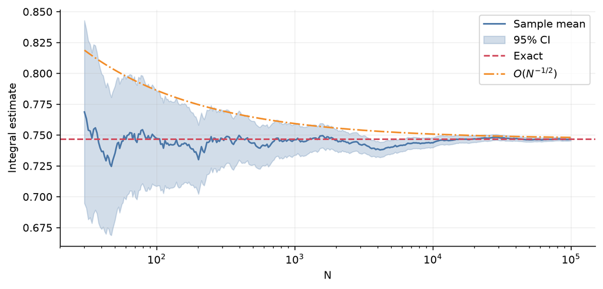

Figure 4: Running mean and 95% CI. The rate reference is drawn above the exact value.

The CI width is $3.92\,\sigma_{H,N}/\sqrt N$. The reference line uses the final sample SD to show how the CI half-width scales with $N$.

## Pricing a European call

The same estimator can price a call in the Black–Scholes model. With $Z\sim N(0,1)$, simulate the terminal price $S_T$ and evaluate the discounted payoff $H(Z)$:
$$S_T=S_0e^{(r-\sigma^2/2)T+\sigma\sqrt T Z},\qquad
H(Z)=e^{-rT}(S_T-K)^+.$$

**NoteTheorem: Black–Scholes price of a European call**

Under the Black–Scholes model, the time-zero call price is
$$C_0=S_0F_Z(d_1)-Ke^{-rT}F_Z(d_2),$$
where $F_Z$ is the standard normal CDF and, with $\nu=\sigma\sqrt T$,
$$d_2=\frac{\log(S_0/K)+(r-\sigma^2/2)T}{\nu},
\qquad d_1=d_2+\nu.$$

**Derivation.** Under the risk-neutral distribution above, $S_T>K$ exactly when $Z>-d_2$. Splitting the payoff into its stock and strike terms gives
$$C_0=e^{-rT}\mathbb E[S_T\mathbf 1_{\{Z>-d_2\}}]
-Ke^{-rT}\Pr(Z>-d_2).$$
By normal symmetry, $\Pr(Z>-d_2)=F_Z(d_2)$. For the stock term, completing the square in the standard normal density gives $e^{\nu z-\nu^2/2}f_Z(z)=f_Z(z-\nu)$. Hence
$$\begin{aligned}
e^{-rT}\mathbb E[S_T\mathbf 1_{\{Z>-d_2\}}]
&=S_0\int_{-d_2}^{\infty}e^{\nu z-\nu^2/2}f_Z(z)\,dz\\
&=S_0\int_{-d_1}^{\infty}f_Z(t)\,dt=S_0F_Z(d_1).
\end{aligned}$$

**Benchmark calculation.** With $(S_0,K,r,\sigma,T)=(95,100,0.01,0.4,1)$, we get $d_2\approx-0.303233$ and $d_1\approx0.096767$. Evaluating $95F_Z(d_1)-100e^{-0.01}F_Z(d_2)$ gives $C_0\approx13.455050$.

The experiment compares the Monte Carlo estimates at $N=10{,}000$ and $100{,}000$ paths with this benchmark.

**Show Python code**

```python
s0,k,r,sigma,T=95.,100.,.01,.4,1.
drift=(r-sigma**2/2)*T
vol=sigma*sqrt(T)
discount=exp(-r*T)
def payoff(z):
    st=s0*np.exp(drift+vol*np.asarray(z))
    return discount*np.maximum(st-k,0)
def Phi(t): return .5*(1+erf(t/sqrt(2)))
d1=(log(s0/k)+(r+sigma**2/2)*T)/vol
d2=d1-vol
exact5=s0*Phi(d1)-k*discount*Phi(d2)
rng=np.random.default_rng(490705)
w5=payoff(rng.standard_normal(100_000))
table([[n,*stats(w5[:n])] for n in [10_000,100_000]],
      ["N","Price estimate","Payoff SD","SE","95% lower","95% upper"])
print(f"Black–Scholes benchmark: {exact5:.6f}")
```

|  | N | Price estimate | Payoff SD | SE | 95% lower | 95% upper |
| --- | --- | --- | --- | --- | --- | --- |
| 0 | 10000 | 13.267172 | 26.497851 | 0.264979 | 12.747814 | 13.786529 |
| 1 | 100000 | 13.439328 | 27.220361 | 0.086078 | 13.270615 | 13.608042 |

```
Black–Scholes benchmark: 13.455050
```

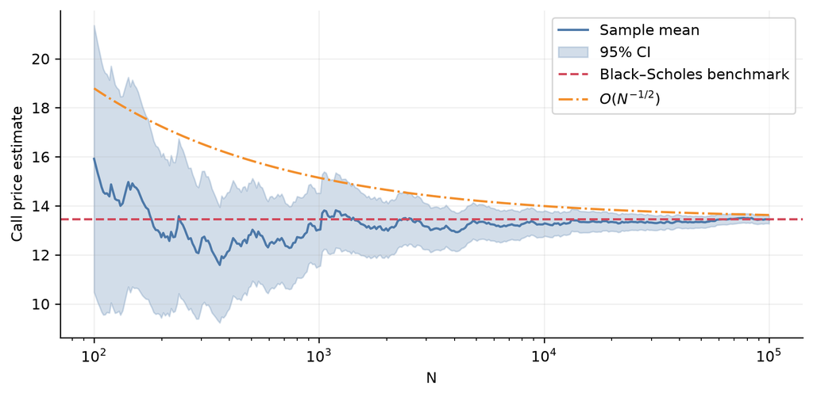

Figure 5: Running call-price estimate and 95% CI. The rate reference is drawn above the Black–Scholes benchmark.

The tenfold increase in paths divides the standard error by about $\sqrt{10}$. Reducing the standard error by a factor of ten using this estimator would take 100 times as many paths.

## Antithetic variates

**NoteDefinitions: Covariance and correlation**

The joint CDF $F_{X,Y}(x,y)=\Pr(X\le x,\,Y\le y)$ describes how $X$ and $Y$ are distributed together. For variables with finite second moments, define
$$\operatorname{Cov}(X,Y)=\mathbb E[(X-\mu_X)(Y-\mu_Y)],
\qquad
\operatorname{Corr}(X,Y)=\frac{\operatorname{Cov}(X,Y)}{\sigma_X\sigma_Y}$$
with correlation defined when $\sigma_X,\sigma_Y>0$. Correlation lies in $[-1,1]$ and measures the direction and strength of the linear relationship. In particular, $\operatorname{Cov}(X,X)=\sigma_X^2$.

For paired observations $(X_i,Y_i)$, the sample covariance and sample correlation are
$$C_N(X,Y)=\frac{1}{N-1}\sum_{i=1}^N(X_i-\mu_{X,N})(Y_i-\mu_{Y,N}),
\qquad
\rho_N(X,Y)=\frac{C_N(X,Y)}{\sigma_{X,N}\sigma_{Y,N}}$$
when the sample standard deviations in the denominator are positive.

**NoteAlgorithm: Antithetic variates**

To estimate $\theta=\mathbb E[h(X)]$:

1. Generate $N$ independent pairs $(X_i,X_i')$. Give both members the same marginal distribution as $X$ and choose the pairing so that $h(X_i)$ and $h(X_i')$ are negatively correlated. For monotone $h$, common choices are $(U,1-U)$ for a uniform draw and $(Z,-Z)$ for a standard normal draw.
2. Form $A_i=(h(X_i)+h(X_i'))/2$ and return $\widehat\theta_N=\mu_{A,N}$.
3. Estimate the standard error as $\sigma_{A,N}/\sqrt N$ from the $N$ pair averages. An approximate 95% CI is $\widehat\theta_N\pm1.96\,\sigma_{A,N}/\sqrt N$.

If $\operatorname{Var}(h(X))=\sigma_h^2$, each pair average has variance $\sigma_h^2(1+\rho)/2$, where $\rho$ is the within-pair correlation. At the same cost of $2N$ evaluations of $h$, the estimator variance is $1+\rho$ times that of crude Monte Carlo.

**Pairing call payoffs.** Revisit the European call with 10,000 pairs $(Z_i,-Z_i)$. Normal symmetry gives $Z\stackrel d=-Z$. The call payoff $H(Z)$ is nondecreasing in $Z$, while $H(-Z)$ is nonincreasing, so their covariance is nonpositive. Use $A_i=(H(Z_i)+H(-Z_i))/2$ as the independent observations for the estimate and CI.

**Show Python code**

```python
rng=np.random.default_rng(490706)
z6=rng.standard_normal(10_000)
pplus,pminus=payoff(z6),payoff(-z6)
pairs=(pplus+pminus)/2
rng_fair=np.random.default_rng(49070620)
crude20k=payoff(rng_fair.standard_normal(20_000))
comparisons=[("Crude, 10,000 paths from the baseline",w5[:10_000]),
             ("Crude, same 10,000 base Z",pplus),
             ("Antithetic, 10,000 pairs",pairs),
             ("Crude, 20,000 independent paths",crude20k)]
table([[name,len(v),*stats(v)] for name,v in comparisons],
      ["Method","Independent units","Price","Sample SD","SE","95% lower","95% upper"])
print(f"Within-pair payoff correlation: {np.corrcoef(pplus,pminus)[0,1]:.6f}")
```

|  | Method | Independent units | Price | Sample SD | SE | 95% lower | 95% upper |
| --- | --- | --- | --- | --- | --- | --- | --- |
| 0 | Crude, 10,000 paths from the baseline | 10000 | 13.267172 | 26.497851 | 0.264979 | 12.747814 | 13.786529 |
| 1 | Crude, same 10,000 base Z | 10000 | 13.603578 | 27.161508 | 0.271615 | 13.071212 | 14.135943 |
| 2 | Antithetic, 10,000 pairs | 10000 | 13.646271 | 16.678473 | 0.166785 | 13.319373 | 13.973169 |
| 3 | Crude, 20,000 independent paths | 20000 | 13.481256 | 27.080626 | 0.191489 | 13.105938 | 13.856574 |

```
Within-pair payoff correlation: -0.250803
```

Each pair costs two payoff evaluations. The figure compares both methods at the same number of evaluations, using the CI widths to show the difference in standard error.

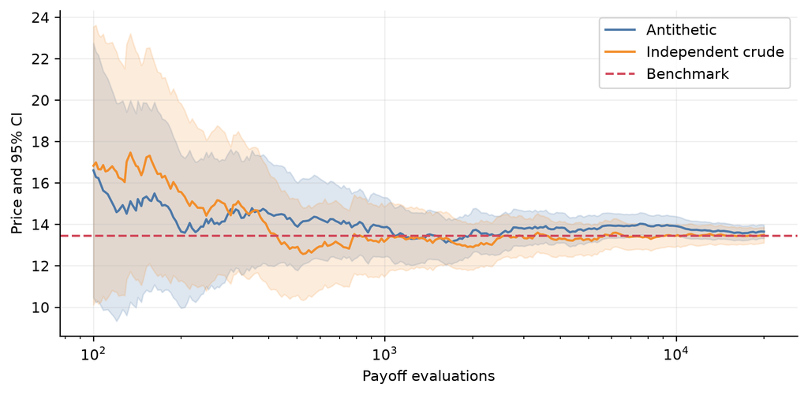

Figure 6: Antithetic versus crude MC at equal payoff cost.

## Control variates

**NoteAlgorithm: Control variates**

To estimate $\theta=\mathbb E[H]$, choose a control $Y$ computed from the same simulation as $H$, with known mean $\mu_Y$ and strong correlation with $H$.

1. Generate independent pairs $(H_i,Y_i)$.
2. Choose the coefficient $c$. The variance-minimizing choice is $c^*=-\operatorname{Cov}(H,Y)/\operatorname{Var}(Y)$ for $\operatorname{Var}(Y)>0$. When these moments are unknown, use $\widehat c=-C_N(H,Y)/\sigma_{Y,N}^2$ if $\sigma_{Y,N}^2>0$.
3. Form $H_i^*=H_i+c(Y_i-\mu_Y)$ and return $\widehat\theta_N=\mu_{H^*,N}$. Estimate its standard error as $\sigma_{H^*,N}/\sqrt N$.

For fixed $c$, the correction has mean zero. At $c=c^*$, the variance of each adjusted value is $\operatorname{Var}(H)(1-\rho^2)$, where $\rho=\operatorname{Corr}(H,Y)$.

**An exponential moment.** To estimate $\mathbb E[X^{0.9}]$ for $X\sim\mathrm{Exp}(1)$, use $Y=X$ as the control. Its mean is $1$, and its values move closely with $X^{0.9}$. From each inverse transform draw $X_i=-\ln(1-U_i)$, compute both $H_i=X_i^{0.9}$ and $Y_i=X_i$.

**Show Python code**

```python
rng=np.random.default_rng(490707)
x7=-np.log1p(-rng.random(10_000))
h7=x7**.9
chat=-np.cov(h7,x7,ddof=1)[0,1]/np.var(x7,ddof=1)
adjusted7=h7+chat*(x7-1)
exact7=gamma(1.9)
table([["Crude",*stats(h7)[:3]],["Control variate",*stats(adjusted7)[:3]]],
      ["Method","Estimate","Sample SD","SE"])
print(f"Sample c: {chat:.6f}; analytic c*: {-0.9*exact7:.6f}")
print(f"Exact target Γ(1.9): {exact7:.6f}")
```

|  | Method | Estimate | Sample SD | SE |
| --- | --- | --- | --- | --- |
| 0 | Crude | 0.985239 | 0.884294 | 0.008843 |
| 1 | Control variate | 0.962008 | 0.048498 | 0.000485 |

```
Sample c: -0.863741; analytic c*: -0.865589
Exact target Γ(1.9): 0.961766
```

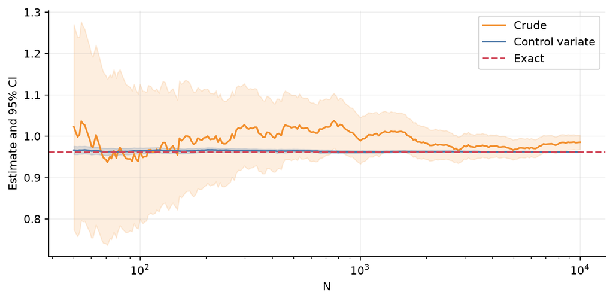

Figure 7: Crude versus control-variate estimates and 95% CIs.

The exact moment is $\Gamma(1.9)$ and the optimal coefficient is $-0.9\Gamma(1.9)$. The plot fits $\widehat c$ on the full sample and uses that same coefficient at every displayed $N$. Fitting the coefficient on the estimation sample can introduce finite-sample bias.

## Importance sampling

**NoteAlgorithm: Importance sampling**

To estimate $\theta=\mathbb E[h(X)]$ for a target $X$ with density $f_X$, choose a proposal $Y$ with density $f_Y$. Require $f_Y$ to be positive almost everywhere that $h(x)f_X(x)\ne 0$. Put more proposal mass where $|h(x)|f_X(x)$ is large.

1. Draw independent $Y_1,\ldots,Y_N$ from $f_Y$.
2. Compute the weighted values $W_i=h(Y_i)f_X(Y_i)/f_Y(Y_i)$.
3. Return $\widehat\theta_N=\mu_{W,N}$. If $W_i$ has a finite second moment, use $\sigma_{W,N}/\sqrt N$ as the estimated standard error.

The weight accounts for the change of sampling density:
$$\mathbb E\!\left[h(Y)\frac{f_X(Y)}{f_Y(Y)}\right]
=\int h(y)f_X(y)\,dy=\theta.$$

**A rare normal tail event.** To estimate $\Pr(Z>4)$ for $Z\sim N(0,1)$, move the proposal mean to the threshold. About half the draws from $Y\sim N(4,1)$ exceed $4$. Since $f_Y(y)=f_Z(y-4)$, the likelihood ratio is $f_Z(Y)/f_Y(Y)=e^{-4Y+8}$, giving $W=\mathbf{1}_{\{Y>4\}}e^{-4Y+8}$. Both methods use 100,000 draws.

**Show Python code**

```python
rng = np.random.default_rng(490708)
n8 = 100_000
z8 = rng.standard_normal(n8)
y8 = rng.normal(loc=4, scale=1, size=n8)
crude8 = (z8 > 4).astype(float)
weights8 = (y8 > 4) * np.exp(-4*y8 + 8)
exact8 = 0.5 * erfc(4 / sqrt(2))

rows8 = []
for name, values in [("Crude", crude8), ("Importance sampling", weights8)]:
    estimate, _, se, _, _ = stats(values)
    rows8.append([name, np.count_nonzero(values), f"{estimate:.3e}", f"{se:.3e}"])
table(rows8, ["Method", "Draws above 4", "Estimate", "SE"])
print(f"Exact tail probability: {exact8:.8g}")
```

|  | Method | Draws above 4 | Estimate | SE |
| --- | --- | --- | --- | --- |
| 0 | Crude | 4 | 4.000e-05 | 2.000e-05 |
| 1 | Importance sampling | 49645 | 3.152e-05 | 2.119e-07 |

```
Exact tail probability: 3.1671242e-05
```

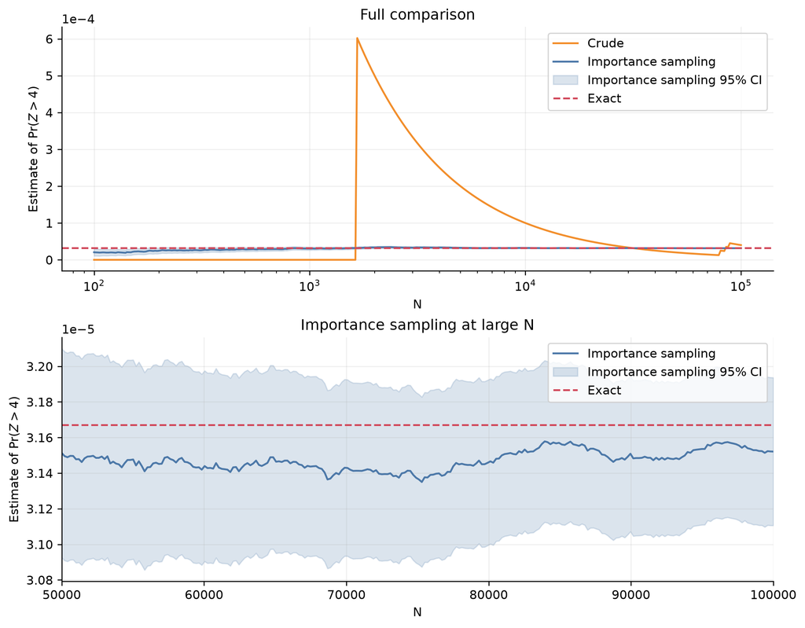

Figure 8: The top panel compares the running estimates at equal sample sizes. The bottom panel zooms in on the importance sampling estimate, 95% CI, and exact probability for N from 50,000 to 100,000.

The shifted proposal produces more tail observations and gives a smaller standard error in this experiment. With only a few crude hits, a normal approximation for the crude CI can be poor.